# Life Expectancy Regression Model

Wennie

May 28, 2022

## Introduction

This data-set contain factors affecting life expectancy with the consideration of demographic variables, income composition, mortality rates, economic factors, immunization affect by formulating a regression model.

The data-set aims to answer the following key questions:

1. Does various predicting factors which has been chosen initially really affect the Life expectancy? What are the predicting variables actually affecting the life expectancy?
2. Should a country having a lower life expectancy value(<65) increase its healthcare expenditure in order to improve its average lifespan?
3. Does Life Expectancy has positive or negative correlation with eating habits, lifestyle, exercise, smoking, drinking alcohol etc.
4. Do densely populated countries tend to have lower life expectancy?

The data can be found in : `https://www.kaggle.com/datasets/kumarajarshi/life-expectancy-who`

## Data Preparation & EDA

```r
library(dplyr)
library(ggplot2)
library(GGally)
library(tidyr)
library(MLmetrics)
library(car)
library(rmarkdown)
```

```r
options(scipen = 999)
```

load the data set

```r
life <- read.csv("Life Expectancy Data.csv")
paged_table(life)
```

| Country | Year | Status | Life.expectancy | Adult.Mortality | infant.deaths | Alcohol | percentage.expenditure | Hepatitis.B | Measles | BMI | under.five.deaths | Polio | Total.expenditure | Diphtheria | HIV.AIDS | GDP | Population | thinness..1.19.years | thinness.5.9.years | Income.composition.of.resources | Schooling |
| --- | --- | --- | --- | --- | --- | --- | --- | --- | --- | --- | --- | --- | --- | --- | --- | --- | --- | --- | --- | --- | --- |
| Afghanistan | 2015 | Developing | 65.0 | 263 | 62 | 0.01 | 71.27962362 | 65 | 1154 | 19.1 | 83 | 6 | 8.16 | 65 | 0.1 | 584.259210 | 33736494.00 | 17.2 | 17.3 | 0.479 | 10.1 |
| Afghanistan | 2014 | Developing | 59.9 | 271 | 64 | 0.01 | 73.52358168 | 62 | 492 | 18.6 | 86 | 58 | 8.18 | 62 | 0.1 | 612.696514 | 327582.00 | 17.5 | 17.5 | 0.476 | 10.0 |
| Afghanistan | 2013 | Developing | 59.9 | 268 | 66 | 0.01 | 73.21924272 | 64 | 430 | 18.1 | 89 | 62 | 8.13 | 64 | 0.1 | 631.744976 | 31731688.00 | 17.7 | 17.7 | 0.470 | 9.9 |
| Afghanistan | 2012 | Developing | 59.5 | 272 | 69 | 0.01 | 78.18421530 | 67 | 2787 | 17.6 | 93 | 67 | 8.52 | 67 | 0.1 | 669.959000 | 3696958.00 | 17.9 | 18.0 | 0.463 | 9.8 |
| Afghanistan | 2011 | Developing | 59.2 | 275 | 71 | 0.01 | 7.09710870 | 68 | 3013 | 17.2 | 97 | 68 | 7.87 | 68 | 0.1 | 63.537231 | 2978599.00 | 18.2 | 18.2 | 0.454 | 9.5 |
| Afghanistan | 2010 | Developing | 58.8 | 279 | 74 | 0.01 | 79.67936736 | 66 | 1989 | 16.7 | 102 | 66 | 9.20 | 66 | 0.1 | 553.328940 | 2883167.00 | 18.4 | 18.4 | 0.448 | 9.2 |
| Afghanistan | 2009 | Developing | 58.6 | 281 | 77 | 0.01 | 56.76221682 | 63 | 2861 | 16.2 | 106 | 63 | 9.42 | 63 | 0.1 | 445.893298 | 284331.00 | 18.6 | 18.7 | 0.434 | 8.9 |
| Afghanistan | 2008 | Developing | 58.1 | 287 | 80 | 0.03 | 25.87392536 | 64 | 1599 | 15.7 | 110 | 64 | 8.33 | 64 | 0.1 | 373.361116 | 2729431.00 | 18.8 | 18.9 | 0.433 | 8.7 |
| Afghanistan | 2007 | Developing | 57.5 | 295 | 82 | 0.02 | 10.91015598 | 63 | 1141 | 15.2 | 113 | 63 | 6.73 | 63 | 0.1 | 369.835796 | 26616792.00 | 19.0 | 19.1 | 0.415 | 8.4 |
| Afghanistan | 2006 | Developing | 57.3 | 295 | 84 | 0.03 | 17.17151751 | 64 | 1990 | 14.7 | 116 | 58 | 7.43 | 58 | 0.1 | 272.563770 | 2589345.00 | 19.2 | 19.3 | 0.405 | 8.1 |

[output cut: 2928 more lines]

check the datatypes of each column

```r
str(life)
```

```
## 'data.frame':    2938 obs. of  22 variables:
##  $ Country                        : chr  "Afghanistan" "Afghanistan" "Afghanistan" "Afghanistan" ...
##  $ Year                           : int  2015 2014 2013 2012 2011 2010 2009 2008 2007 2006 ...
##  $ Status                         : chr  "Developing" "Developing" "Developing" "Developing" ...
##  $ Life.expectancy                : num  65 59.9 59.9 59.5 59.2 58.8 58.6 58.1 57.5 57.3 ...
##  $ Adult.Mortality                : int  263 271 268 272 275 279 281 287 295 295 ...
##  $ infant.deaths                  : int  62 64 66 69 71 74 77 80 82 84 ...
##  $ Alcohol                        : num  0.01 0.01 0.01 0.01 0.01 0.01 0.01 0.03 0.02 0.03 ...
##  $ percentage.expenditure         : num  71.3 73.5 73.2 78.2 7.1 ...
##  $ Hepatitis.B                    : int  65 62 64 67 68 66 63 64 63 64 ...
##  $ Measles                        : int  1154 492 430 2787 3013 1989 2861 1599 1141 1990 ...
##  $ BMI                            : num  19.1 18.6 18.1 17.6 17.2 16.7 16.2 15.7 15.2 14.7 ...
##  $ under.five.deaths              : int  83 86 89 93 97 102 106 110 113 116 ...
##  $ Polio                          : int  6 58 62 67 68 66 63 64 63 58 ...
##  $ Total.expenditure              : num  8.16 8.18 8.13 8.52 7.87 9.2 9.42 8.33 6.73 7.43 ...
##  $ Diphtheria                     : int  65 62 64 67 68 66 63 64 63 58 ...
##  $ HIV.AIDS                       : num  0.1 0.1 0.1 0.1 0.1 0.1 0.1 0.1 0.1 0.1 ...
##  $ GDP                            : num  584.3 612.7 631.7 670 63.5 ...
##  $ Population                     : num  33736494 327582 31731688 3696958 2978599 ...
##  $ thinness..1.19.years           : num  17.2 17.5 17.7 17.9 18.2 18.4 18.6 18.8 19 19.2 ...
##  $ thinness.5.9.years             : num  17.3 17.5 17.7 18 18.2 18.4 18.7 18.9 19.1 19.3 ...
##  $ Income.composition.of.resources: num  0.479 0.476 0.47 0.463 0.454 0.448 0.434 0.433 0.415 0.405 ...
##  $ Schooling                      : num  10.1 10 9.9 9.8 9.5 9.2 8.9 8.7 8.4 8.1 ...
```

check the missing values in the data `life`

```r
colSums(is.na(life))
```

```
##                         Country                            Year
##                               0                               0
##                          Status                 Life.expectancy
##                               0                              10
##                 Adult.Mortality                   infant.deaths
##                              10                               0
##                         Alcohol          percentage.expenditure
##                             194                               0
##                     Hepatitis.B                         Measles
##                             553                               0
##                             BMI               under.five.deaths
##                              34                               0
##                           Polio               Total.expenditure
##                              19                             226
##                      Diphtheria                        HIV.AIDS
##                              19                               0
##                             GDP                      Population
##                             448                             652
##            thinness..1.19.years              thinness.5.9.years
##                              34                              34
## Income.composition.of.resources                       Schooling
##                             167                             163
```

There is a lot of missing value in the data, so we can drop the NA. Furthermore, the data is consist of `22 variables`, here our target variable is none other than `life expectancy`. Besides, we will delete the unused columns such as `Country, Status, and Year` and will be assigned to new variable : `life_exp`

```r
life <- life %>%
  drop_na()
```

```r
life_exp <- life %>%
  select(-c("Country","Year","Status"))
```

## Developed vs Developing Country Life Expectancy

Here, we are going to see the life expectancy rate in Developed and Developing Country from the `Status` columns

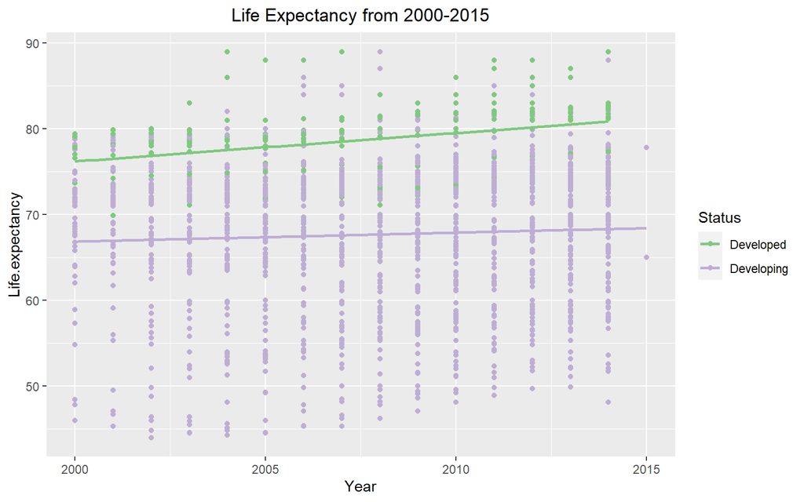

```r
ggplot(data=life,mapping=aes(Year,Life.expectancy,color=Status))+
  geom_point()+
  scale_color_brewer(palette="Accent")+
  geom_smooth(method="lm",se=FALSE)+
  labs(title="Life Expectancy from 2000-2015")+
  theme(plot.title = element_text(hjust = 0.5))
```

Let’s have a look at the adult mortality between both groups

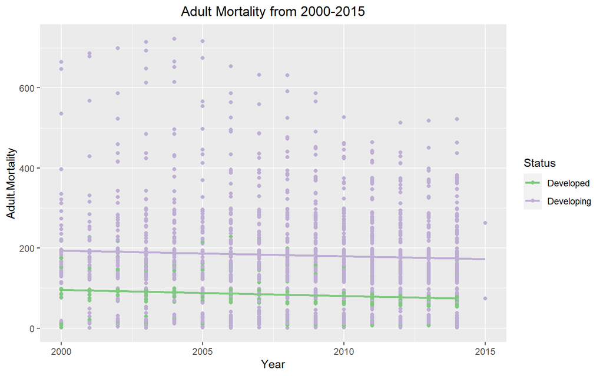

```r
ggplot(data=life,mapping=aes(Year,Adult.Mortality,color=Status))+
  geom_point()+
  scale_color_brewer(palette="Accent")+
  geom_smooth(method="lm",se=FALSE)+
  labs(title="Adult Mortality from 2000-2015")+
  theme(plot.title = element_text(hjust = 0.5))
```

## Modeling

### 1. Life Expectancy and Total Expenditure Correlation

firstly, lets select only two columns : `Life Expectancy` & `Total Expenditure` as we will only see the correlation between this two variables

```r
life_low <- life_exp %>%
  filter(Life.expectancy < 65) %>%
  select(c("Life.expectancy","Total.expenditure"))
```

then, we will build model with `Life Expectancy` as the `target variable` while `Total Expenditure` as the `predictor variable`

```r
model_low <- lm(formula = Life.expectancy~Total.expenditure, data = life_low)
summary(model_low)
```

```
##
## Call:
## lm(formula = Life.expectancy ~ Total.expenditure, data = life_low)
##
## Residuals:
##      Min       1Q   Median       3Q      Max
## -13.7376  -2.9252   0.8084   4.4974   8.8206
##
## Coefficients:
##                   Estimate Std. Error t value             Pr(>|t|)
## (Intercept)        59.4368     0.6787  87.573 < 0.0000000000000002 ***
## Total.expenditure  -0.3565     0.1096  -3.253              0.00123 **
## ---
## Signif. codes:  0 '***' 0.001 '**' 0.01 '*' 0.05 '.' 0.1 ' ' 1
##
## Residual standard error: 5.397 on 437 degrees of freedom
## Multiple R-squared:  0.02364,    Adjusted R-squared:  0.02141
## F-statistic: 10.58 on 1 and 437 DF,  p-value: 0.00123
```

From the model summary, we can see that `Total Expenditure` does not depicts the target variable as the `adjusted R-Squared` relatively low. However let’s see the plot for better understanding

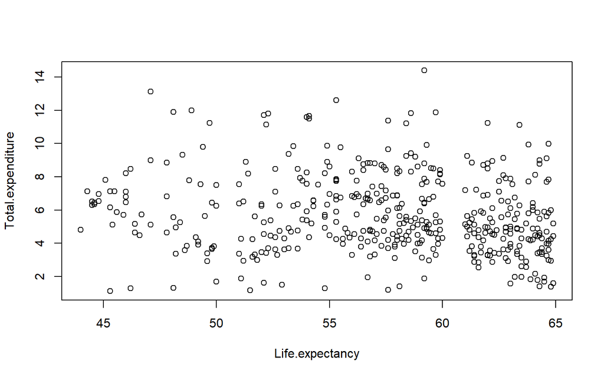

```r
plot(life_low)
```

it is clear that total expenditure does not affect the life span, and negatively corelated

### 2. Choosing best-fit model for target

In the begining, we will build one model with all predictor then we will conduct `Multicollinearity Test` so that we can omit some columns with high correlation one another.

```r
model_all <- lm(formula = Life.expectancy~., data = life_exp)
summary(model_all)
```

```
##
## Call:
## lm(formula = Life.expectancy ~ ., data = life_exp)
##
## Residuals:
##      Min       1Q   Median       3Q      Max
## -17.0176  -2.0454  -0.0185   2.2260  11.9157
##
## Coefficients:
##                                         Estimate       Std. Error t value
## (Intercept)                     53.2815590198721  0.7358126406486  72.412
## Adult.Mortality                 -0.0168885301997  0.0009472912705 -17.828
## infant.deaths                    0.0936938378330  0.0106765961044   8.776
## Alcohol                         -0.0543483450424  0.0306070454392  -1.776
## percentage.expenditure           0.0003776826235  0.0001804691153   2.093
## Hepatitis.B                     -0.0055824997053  0.0044461852137  -1.256
## Measles                         -0.0000086173382  0.0000108065835  -0.797
## BMI                              0.0334980599049  0.0060106760259   5.573
## under.five.deaths               -0.0704701961145  0.0077282061768  -9.119
## Polio                            0.0078363788927  0.0051632463325   1.518
## Total.expenditure                0.0797522210770  0.0407415696170   1.958
## Diphtheria                       0.0143889186959  0.0059383017027   2.423
## HIV.AIDS                        -0.4382980476500  0.0178758984580 -24.519
## GDP                              0.0000138327405  0.0000283772875   0.487
## Population                      -0.0000000006917  0.0000000017525  -0.395
## thinness..1.19.years            -0.0086702286839  0.0531024439158  -0.163
## thinness.5.9.years              -0.0512278223876  0.0524179265759  -0.977
## Income.composition.of.resources  9.8241467234536  0.8339594781239  11.780
## Schooling                        0.8783349550519  0.0593903821788  14.789
##                                             Pr(>|t|)
## (Intercept)                     < 0.0000000000000002 ***
## Adult.Mortality                 < 0.0000000000000002 ***
## infant.deaths                   < 0.0000000000000002 ***
## Alcohol                                       0.0760 .
## percentage.expenditure                        0.0365 *
## Hepatitis.B                                   0.2095
## Measles                                       0.4253
## BMI                                     0.0000000292 ***
## under.five.deaths               < 0.0000000000000002 ***
## Polio                                         0.1293
## Total.expenditure                             0.0505 .
## Diphtheria                                    0.0155 *
## HIV.AIDS                        < 0.0000000000000002 ***
## GDP                                           0.6260
## Population                                    0.6931
## thinness..1.19.years                          0.8703
## thinness.5.9.years                            0.3286
## Income.composition.of.resources < 0.0000000000000002 ***
## Schooling                       < 0.0000000000000002 ***
## ---
## Signif. codes:  0 '***' 0.001 '**' 0.01 '*' 0.05 '.' 0.1 ' ' 1
##
## Residual standard error: 3.596 on 1630 degrees of freedom
## Multiple R-squared:  0.8347, Adjusted R-squared:  0.8329
## F-statistic: 457.4 on 18 and 1630 DF,  p-value: < 0.00000000000000022
```

```r
vif(model_all)
```

```
##                 Adult.Mortality                   infant.deaths
##                        1.795984                      212.177699
##                         Alcohol          percentage.expenditure
##                        1.938381                       12.847295
##                     Hepatitis.B                         Measles
##                        1.651864                        1.514114
##                             BMI               under.five.deaths
##                        1.796920                      201.999311
##                           Polio               Total.expenditure
##                        1.712620                        1.118562
##                      Diphtheria                        HIV.AIDS
##                        2.092936                        1.482079
##                             GDP                      Population
##                       13.516874                        1.943391
##            thinness..1.19.years              thinness.5.9.years
##                        7.602562                        7.584519
## Income.composition.of.resources                       Schooling
##                        2.971489                        3.512993
```

We have 2 pair of variables with high value (>10) so we omit one of them

```r
life_exp <- life_exp %>%
  select(-c("percentage.expenditure","under.five.deaths"))
```

Now, the data is ready to go!

Before we build the model, we need to split the data into train dataset and test dataset. We will use the train dataset to train the linear regression model. The test dataset will be used as a comparasion and see if the model get overfit and can not predict new data that hasn’t been seen during training phase. We will 70% of the data as the training data and the rest of it as the testing data.

```r
set.seed(123)
samplesize <- round(0.7 * nrow(life_exp), 0)
index <- sample(seq_len(nrow(life_exp)), size = samplesize)

data_train <- life_exp[index, ]
data_test <- life_exp[-index, ]
```

Below, we will use `ggcorr` to get the insight on which variables most correlated to our target variable

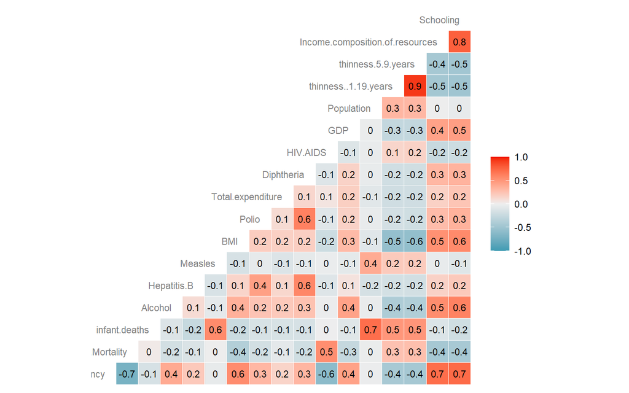

```r
ggcorr(data_train, label = TRUE, label_size = 3, hjust = 1, size = 3, color = "grey50")
```

```r
model_cor <-  lm(formula = Life.expectancy~Schooling + Income.composition.of.resources + HIV.AIDS + BMI + Adult.Mortality, data = data_train)
summary(model_cor)
```

```
##
## Call:
## lm(formula = Life.expectancy ~ Schooling + Income.composition.of.resources +
##     HIV.AIDS + BMI + Adult.Mortality, data = data_train)
##
## Residuals:
##      Min       1Q   Median       3Q      Max
## -13.6586  -2.1296   0.0476   2.2251  11.5009
##
## Coefficients:
##                                  Estimate Std. Error t value
## (Intercept)                     53.203525   0.646257  82.326
## Schooling                        1.004741   0.066450  15.120
## Income.composition.of.resources 10.389611   0.982093  10.579
## HIV.AIDS                        -0.423511   0.020591 -20.567
## BMI                              0.041226   0.007040   5.856
## Adult.Mortality                 -0.019516   0.001159 -16.837
##                                             Pr(>|t|)
## (Intercept)                     < 0.0000000000000002 ***
## Schooling                       < 0.0000000000000002 ***
## Income.composition.of.resources < 0.0000000000000002 ***
## HIV.AIDS                        < 0.0000000000000002 ***
## BMI                                     0.0000000062 ***
## Adult.Mortality                 < 0.0000000000000002 ***
## ---
## Signif. codes:  0 '***' 0.001 '**' 0.01 '*' 0.05 '.' 0.1 ' ' 1
##
## Residual standard error: 3.792 on 1148 degrees of freedom
## Multiple R-squared:  0.8177, Adjusted R-squared:  0.8169
## F-statistic:  1030 on 5 and 1148 DF,  p-value: < 0.00000000000000022
```

Next, let’s build another model with all variables as the predictor!

```r
model_all1 <- lm(formula = Life.expectancy~., data = data_train)
summary(model_all1)
```

```
##
## Call:
## lm(formula = Life.expectancy ~ ., data = data_train)
##
## Residuals:
##      Min       1Q   Median       3Q      Max
## -13.4301  -2.0632   0.0488   2.3458  12.0615
##
## Coefficients:
##                                        Estimate      Std. Error t value
## (Intercept)                     52.630454612090  0.893662383673  58.893
## Adult.Mortality                 -0.018753675757  0.001140494418 -16.443
## infant.deaths                   -0.003946595414  0.001415661815  -2.788
## Alcohol                         -0.098050854704  0.036795918415  -2.665
## Hepatitis.B                     -0.001430391505  0.005519089870  -0.259
## Measles                          0.000026170606  0.000013502066   1.938
## BMI                              0.036361321707  0.007488119925   4.856
## Polio                            0.014953814850  0.006379346370   2.344
## Total.expenditure                0.063045802024  0.050065180579   1.259
## Diphtheria                       0.010125783100  0.007182107989   1.410
## HIV.AIDS                        -0.425373572930  0.020322713751 -20.931
## GDP                              0.000068849479  0.000011163417   6.167
## Population                       0.000000002430  0.000000001897   1.281
## thinness..1.19.years             0.012219124856  0.062913216852   0.194
## thinness.5.9.years              -0.030770519978  0.062292387038  -0.494
## Income.composition.of.resources  9.876337508053  0.991664846403   9.959
## Schooling                        0.904651736169  0.071146745246  12.715
##                                             Pr(>|t|)
## (Intercept)                     < 0.0000000000000002 ***
## Adult.Mortality                 < 0.0000000000000002 ***
## infant.deaths                                0.00539 **
## Alcohol                                      0.00781 **
## Hepatitis.B                                  0.79555
## Measles                                      0.05284 .
## BMI                                   0.000001365941 ***
## Polio                                        0.01924 *
## Total.expenditure                            0.20819
## Diphtheria                                   0.15885
## HIV.AIDS                        < 0.0000000000000002 ***
## GDP                                   0.000000000963 ***
## Population                                   0.20044
## thinness..1.19.years                         0.84604
## thinness.5.9.years                           0.62142
## Income.composition.of.resources < 0.0000000000000002 ***
## Schooling                       < 0.0000000000000002 ***
## ---
## Signif. codes:  0 '***' 0.001 '**' 0.01 '*' 0.05 '.' 0.1 ' ' 1
##
## Residual standard error: 3.691 on 1137 degrees of freedom
## Multiple R-squared:  0.8289, Adjusted R-squared:  0.8265
## F-statistic: 344.3 on 16 and 1137 DF,  p-value: < 0.00000000000000022
```

```r
vif(model_all1)
```

```
##                 Adult.Mortality                   infant.deaths
##                        1.765814                        3.152984
##                         Alcohol                     Hepatitis.B
##                        1.836958                        1.629550
##                         Measles                             BMI
##                        1.499413                        1.838273
##                           Polio               Total.expenditure
##                        1.701747                        1.112782
##                      Diphtheria                        HIV.AIDS
##                        2.057892                        1.462930
##                             GDP                      Population
##                        1.367865                        2.046658
##            thinness..1.19.years              thinness.5.9.years
##                        7.540402                        7.621110
## Income.composition.of.resources                       Schooling
##                        2.854557                        3.334354
```

This time, no Multicollinearity :D

let’s build the third model with diseases as the predictor variable

```r
model_dis <- lm(formula = Life.expectancy~ Alcohol + Hepatitis.B + Measles +
    Polio + Diphtheria + HIV.AIDS , data = data_train)
summary(model_dis)
```

```
##
## Call:
## lm(formula = Life.expectancy ~ Alcohol + Hepatitis.B + Measles +
##     Polio + Diphtheria + HIV.AIDS, data = data_train)
##
## Residuals:
##      Min       1Q   Median       3Q      Max
## -21.2197  -4.0446   0.5889   4.1086  13.9520
##
## Coefficients:
##                Estimate  Std. Error t value             Pr(>|t|)
## (Intercept) 60.11233688  0.81054023  74.163 < 0.0000000000000002 ***
## Alcohol      0.70938476  0.04629155  15.324 < 0.0000000000000002 ***
## Hepatitis.B  0.00086762  0.00885145   0.098             0.921933
## Measles     -0.00002404  0.00001820  -1.321             0.186870
## Polio        0.04718723  0.01027589   4.592           0.00000487 ***
## Diphtheria   0.04252939  0.01159048   3.669             0.000254 ***
## HIV.AIDS    -0.78438026  0.02763614 -28.382 < 0.0000000000000002 ***
## ---
## Signif. codes:  0 '***' 0.001 '**' 0.01 '*' 0.05 '.' 0.1 ' ' 1
##
## Residual standard error: 6.024 on 1147 degrees of freedom
## Multiple R-squared:  0.5402, Adjusted R-squared:  0.5378
## F-statistic: 224.6 on 6 and 1147 DF,  p-value: < 0.00000000000000022
```

Here, we are going to evaluate which model is the best from `adjusted r squared`

```r
summary(model_all1)$adj.r.squared
```

```
## [1] 0.8264878
```

```r
summary(model_cor)$adj.r.squared
```

```
## [1] 0.8168667
```

```r
summary(model_dis)$adj.r.squared
```

```
## [1] 0.5377581
```

in this case, it is apparent that model_all1 will be our model

Here we go! Linear Regression from the data train!

```r
data_train$Prediksi <- predict(model_all1, newdata = data_train %>% select(-Life.expectancy))
```

```r
res_train <- data_train$Prediksi - data_train$Life.expectancy
j <- data.frame(prediksi = data_train$Prediksi,
           actual = data_train$Life.expectancy,
           residual = res_train)
head(j)
```

```
##   prediksi actual   residual
## 1 76.71204   81.0 -4.2879606
## 2 71.66441   74.4 -2.7355914
## 3 64.66162   59.7  4.9616227
## 4 68.51433   67.7  0.8143344
## 5 67.74798   68.3 -0.5520187
## 6 70.18766   72.7 -2.5123436
```

Next, let’s apply it in our data test!

```r
data_test$Prediksi <- predict(model_all1, newdata = data_test %>% select(-Life.expectancy))
```

```r
res_test <- data_test$Prediksi - data_test$Life.expectancy
w <- data.frame(prediksi = data_test$Prediksi,
           actual = data_test$Life.expectancy,
           residual = res_test)
head(w)
```

```
##   prediksi actual   residual
## 1 63.35625   59.9  3.4562501
## 2 61.78197   58.6  3.1819734
## 3 57.46580   57.0  0.4658001
## 4 63.24017   56.2  7.0401716
## 5 56.92262   55.3  1.6226205
## 6 73.48648   76.2 -2.7135182
```

## Evaluation

### Data Train with all variables as the predictor

```r
RMSE(model_all1$fitted.values, data_train$Life.expectancy)
```

```
## [1] 3.663409
```

```r
MAPE(data_train$Prediksi, data_train$Life.expectancy) * 100
```

```
## [1] 4.226265
```

### Data Test with all variables as the predictor

```r
RMSE(model_all1$fitted.values, data_test$Life.expectancy)
```

```
## [1] 11.73196
```

```r
MAPE(data_test$Prediksi, data_test$Life.expectancy) * 100
```

```
## [1] 4.27312
```

Well the RMSE in our data test is not as good in our data train.

## Model Improvement

let’s implement `step-wise regression`,but first, do not forget to split the data into train and test with 7:3 ratio!

```r
set.seed(123)
samplesize <- round(0.7 * nrow(life_exp), 0)
index <- sample(seq_len(nrow(life_exp)), size = samplesize)

data_train1 <- life_exp[index, ]
data_test1 <- life_exp[-index, ]
```

```r
# model without predictor
model_life_non <- lm(formula = Life.expectancy ~ 1, data = data_train1)
# model with all predictor
model_life_all <- lm(formula = Life.expectancy ~ ., data = data_train1)
```

```r
both_model <- step(model_life_non, direction = "both",
     scope = list(lower = model_life_non, upper = model_life_all), trace = 0)

summary(both_model)
```

```
##
## Call:
## lm(formula = Life.expectancy ~ Schooling + HIV.AIDS + Adult.Mortality +
##     Income.composition.of.resources + GDP + BMI + Polio + infant.deaths +
##     Alcohol + Measles + Diphtheria, data = data_train1)
##
## Residuals:
##      Min       1Q   Median       3Q      Max
## -13.0691  -2.0623   0.0645   2.3334  12.3195
##
## Coefficients:
##                                    Estimate  Std. Error t value
## (Intercept)                     52.55680497  0.78874069  66.634
## Schooling                        0.91748059  0.07060794  12.994
## HIV.AIDS                        -0.42344904  0.02014489 -21.020
## Adult.Mortality                 -0.01879948  0.00113868 -16.510
## Income.composition.of.resources  9.88446069  0.98369643  10.048
## GDP                              0.00007006  0.00001112   6.300
## BMI                              0.03869031  0.00696994   5.551
## Polio                            0.01491909  0.00629551   2.370
## infant.deaths                   -0.00319034  0.00098901  -3.226
## Alcohol                         -0.09285985  0.03611119  -2.571
## Measles                          0.00002629  0.00001335   1.969
## Diphtheria                       0.00994127  0.00646864   1.537
##                                             Pr(>|t|)
## (Intercept)                     < 0.0000000000000002 ***
## Schooling                       < 0.0000000000000002 ***
## HIV.AIDS                        < 0.0000000000000002 ***
## Adult.Mortality                 < 0.0000000000000002 ***
## Income.composition.of.resources < 0.0000000000000002 ***
## GDP                                   0.000000000425 ***
## BMI                                   0.000000035295 ***
## Polio                                        0.01796 *
## infant.deaths                                0.00129 **
## Alcohol                                      0.01025 *
## Measles                                      0.04918 *
## Diphtheria                                   0.12461
## ---
## Signif. codes:  0 '***' 0.001 '**' 0.01 '*' 0.05 '.' 0.1 ' ' 1
##
## Residual standard error: 3.689 on 1142 degrees of freedom
## Multiple R-squared:  0.8283, Adjusted R-squared:  0.8267
## F-statistic: 500.9 on 11 and 1142 DF,  p-value: < 0.00000000000000022
```

```r
# Backward elimination
backward_model <- step(model_life_all, trace = 0)
summary(backward_model)
```

```
##
## Call:
## lm(formula = Life.expectancy ~ Adult.Mortality + infant.deaths +
##     Alcohol + Measles + BMI + Polio + Diphtheria + HIV.AIDS +
##     GDP + Income.composition.of.resources + Schooling, data = data_train1)
##
## Residuals:
##      Min       1Q   Median       3Q      Max
## -13.0691  -2.0623   0.0645   2.3334  12.3195
##
## Coefficients:
##                                    Estimate  Std. Error t value
## (Intercept)                     52.55680497  0.78874069  66.634
## Adult.Mortality                 -0.01879948  0.00113868 -16.510
## infant.deaths                   -0.00319034  0.00098901  -3.226
## Alcohol                         -0.09285985  0.03611119  -2.571
## Measles                          0.00002629  0.00001335   1.969
## BMI                              0.03869031  0.00696994   5.551
## Polio                            0.01491909  0.00629551   2.370
## Diphtheria                       0.00994127  0.00646864   1.537
## HIV.AIDS                        -0.42344904  0.02014489 -21.020
## GDP                              0.00007006  0.00001112   6.300
## Income.composition.of.resources  9.88446069  0.98369643  10.048
## Schooling                        0.91748059  0.07060794  12.994
##                                             Pr(>|t|)
## (Intercept)                     < 0.0000000000000002 ***
## Adult.Mortality                 < 0.0000000000000002 ***
## infant.deaths                                0.00129 **
## Alcohol                                      0.01025 *
## Measles                                      0.04918 *
## BMI                                   0.000000035295 ***
## Polio                                        0.01796 *
## Diphtheria                                   0.12461
## HIV.AIDS                        < 0.0000000000000002 ***
## GDP                                   0.000000000425 ***
## Income.composition.of.resources < 0.0000000000000002 ***
## Schooling                       < 0.0000000000000002 ***
## ---
## Signif. codes:  0 '***' 0.001 '**' 0.01 '*' 0.05 '.' 0.1 ' ' 1
##
## Residual standard error: 3.689 on 1142 degrees of freedom
## Multiple R-squared:  0.8283, Adjusted R-squared:  0.8267
## F-statistic: 500.9 on 11 and 1142 DF,  p-value: < 0.00000000000000022
```

```r
forward_model <- step(model_life_non, direction = "forward",
     scope = list(lower = model_life_non, upper = model_life_all), trace = 0)
summary(forward_model)
```

```
##
## Call:
## lm(formula = Life.expectancy ~ Schooling + HIV.AIDS + Adult.Mortality +
##     Income.composition.of.resources + GDP + BMI + Polio + infant.deaths +
##     Alcohol + Measles + Diphtheria, data = data_train1)
##
## Residuals:
##      Min       1Q   Median       3Q      Max
## -13.0691  -2.0623   0.0645   2.3334  12.3195
##
## Coefficients:
##                                    Estimate  Std. Error t value
## (Intercept)                     52.55680497  0.78874069  66.634
## Schooling                        0.91748059  0.07060794  12.994
## HIV.AIDS                        -0.42344904  0.02014489 -21.020
## Adult.Mortality                 -0.01879948  0.00113868 -16.510
## Income.composition.of.resources  9.88446069  0.98369643  10.048
## GDP                              0.00007006  0.00001112   6.300
## BMI                              0.03869031  0.00696994   5.551
## Polio                            0.01491909  0.00629551   2.370
## infant.deaths                   -0.00319034  0.00098901  -3.226
## Alcohol                         -0.09285985  0.03611119  -2.571
## Measles                          0.00002629  0.00001335   1.969
## Diphtheria                       0.00994127  0.00646864   1.537
##                                             Pr(>|t|)
## (Intercept)                     < 0.0000000000000002 ***
## Schooling                       < 0.0000000000000002 ***
## HIV.AIDS                        < 0.0000000000000002 ***
## Adult.Mortality                 < 0.0000000000000002 ***
## Income.composition.of.resources < 0.0000000000000002 ***
## GDP                                   0.000000000425 ***
## BMI                                   0.000000035295 ***
## Polio                                        0.01796 *
## infant.deaths                                0.00129 **
## Alcohol                                      0.01025 *
## Measles                                      0.04918 *
## Diphtheria                                   0.12461
## ---
## Signif. codes:  0 '***' 0.001 '**' 0.01 '*' 0.05 '.' 0.1 ' ' 1
##
## Residual standard error: 3.689 on 1142 degrees of freedom
## Multiple R-squared:  0.8283, Adjusted R-squared:  0.8267
## F-statistic: 500.9 on 11 and 1142 DF,  p-value: < 0.00000000000000022
```

```r
library(performance)
compare_performance(backward_model, forward_model, both_model)
```

```
## # Comparison of Model Performance Indices
##
## Name           | Model |      AIC | AIC weights |      BIC | BIC weights |    R2 | R2 (adj.) |  RMSE | Sigma
## ------------------------------------------------------------------------------------------------------------
## backward_model |    lm | 6301.489 |       0.333 | 6367.152 |       0.333 | 0.828 |     0.827 | 3.670 | 3.689
## forward_model  |    lm | 6301.489 |       0.333 | 6367.152 |       0.333 | 0.828 |     0.827 | 3.670 | 3.689
## both_model     |    lm | 6301.489 |       0.333 | 6367.152 |       0.333 | 0.828 |     0.827 | 3.670 | 3.689
```

all model perform well, but we will take `both_model` to go to the next stage XD

```r
data_train1$Prediksi <- predict(both_model, newdata = data_train1 %>% select(-Life.expectancy))
```

```r
res_train1 <- data_train1$Prediksi - data_train1$Life.expectancy
k<- data.frame(prediksi = data_train1$Prediksi,
           actual = data_train1$Life.expectancy,
           residual = res_train1)
head(k)
```

```
##   prediksi actual   residual
## 1 76.67053   81.0 -4.3294680
## 2 71.59586   74.4 -2.8041369
## 3 64.72622   59.7  5.0262221
## 4 68.58737   67.7  0.8873700
## 5 68.01638   68.3 -0.2836228
## 6 70.33813   72.7 -2.3618692
```

```r
RMSE(both_model$fitted.values, data_train1$Life.expectancy)
```

```
## [1] 3.669581
```

```r
MAPE(data_train1$Prediksi, data_train1$Life.expectancy) * 100
```

```
## [1] 4.222297
```

```r
data_test1$Prediksi <- predict(both_model, newdata = data_test1 %>% select(-Life.expectancy))
```

```r
res_test1 <- data_test1$Prediksi - data_test1$Life.expectancy
h <- data.frame(prediksi = data_test1$Prediksi,
           actual = data_test1$Life.expectancy,
           residual = res_test1)
```

```r
RMSE(both_model$fitted.values, data_test1$Life.expectancy)
```

```
## [1] 11.73672
```

```r
MAPE(data_test1$Prediksi, data_test1$Life.expectancy) * 100
```

```
## [1] 4.285507
```

well, it is still the same with the model_all1 performance :(, but yeah let’s move on

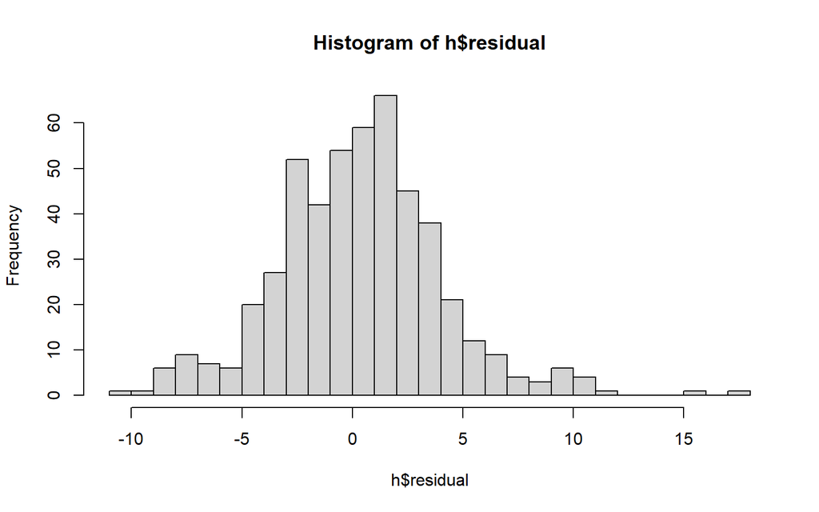

```r
hist(h$residual, breaks=30)
```

From the graph, we can see that the data is not normaly distributed, let’s run `shapiro test` to be more precise!

H0: error is distributed normally H1: error is not distributed normally

```r
shapiro.test(h$residual)
```

```
##
##  Shapiro-Wilk normality test
##
## data:  h$residual
## W = 0.98018, p-value = 0.000002859
```

well, p-value < alpha (0.05) so we need to reject H0

```r
library(lmtest)
```

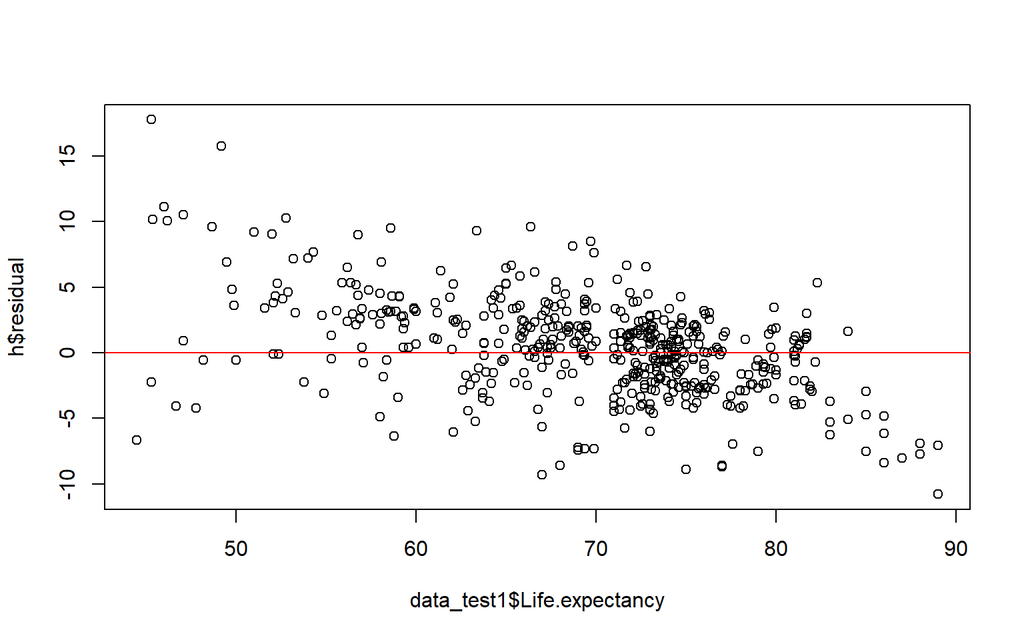

```r
plot(data_test1$Life.expectancy, h$residual)
abline(h = 0, col = "red")
```

$$H_0: Homoscedasticity\\
H_1: Heteroscedasticity$$

```r
bptest(both_model)
```

```
##
##  studentized Breusch-Pagan test
##
## data:  both_model
## BP = 119.4, df = 11, p-value < 0.00000000000000022
```

The p-value is again lower than the alpha so our data is Heteroscedasticity, means that our error variation is not constantly distributed but performing pattern

```r
vif(both_model)
```

```
##                       Schooling                        HIV.AIDS
##                        3.287398                        1.438910
##                 Adult.Mortality Income.composition.of.resources
##                        1.761999                        2.811737
##                             GDP                             BMI
##                        1.359024                        1.594287
##                           Polio                   infant.deaths
##                        1.659005                        1.540441
##                         Alcohol                         Measles
##                        1.771036                        1.467346
##                      Diphtheria
##                        1.671044
```

no multicollinearity as no value is higher than 10

## Conclusion

We have already learn how to build a linear regression model and what need to be concerned when building the model.